# Hazardous/Dangerous Asteroid Detection with Machine Learning

Ardian the Great

August 25th, 2023

This machine learning project focuses on a critical challenge: detecting hazardous asteroids. The primary goal of this endeavor is to construct a robust predictive model with the capability to identify asteroids that pose a threat to Earth. By accurately pinpointing potential hazards, the model aims to enhance decision-making in planetary defense strategies, mitigate potential risks, and facilitate informed actions in the realm of planetary safety.

These are some valuable advantages that are offered by the result of this project:

> - `Early Alerts:` Timely warnings for potential asteroid threats.
> - `Impact Reduction:` Minimized risk from hazardous asteroids.
> - `Informed Decisions:` Data-driven choices for emergency responses.
> - `Planetary Safety:` Improved defense against celestial hazards.
> - `Scientific Insights:` Enhanced understanding of asteroid behavior.
> - `Public Awareness:` Raised awareness and educational opportunities.
> - `Global Collaboration:` International partnerships for defense efforts.
> - `Mission Planning:` Optimized space mission targeting.
> - `Policy Influence:` Guidance for planetary defense policies.
> - `Inspiration:` Catalyst for innovation and space exploration.

## **Data Pre-processing**

### Import used libraries

```r
library(dplyr)
library(caret)
library(inspectdf)
library(Ardian)
library(GGally)
library(e1071)
library(randomForest)
```

### Read the data

The data is from `NASA API` from http://neo.jpl.nasa.gov/. This API is maintained by SpaceRocks Team: David Greenfield, Arezu Sarvestani, Jason English and Peter Baunach.

```r
asteroids <- read.csv("nasa.csv", stringsAsFactors = T)
```

### Inspect the data

#### Top 6 rows

```r
asteroids %>% head()
```

|  | Neo.Reference.ID | Name | Absolute.Magnitude | Est.Dia.in.KM.min. | Est.Dia.in.KM.max. | Est.Dia.in.M.min. | Est.Dia.in.M.max. | Est.Dia.in.Miles.min. | Est.Dia.in.Miles.max. | Est.Dia.in.Feet.min. | Est.Dia.in.Feet.max. | Close.Approach.Date | Epoch.Date.Close.Approach | Relative.Velocity.km.per.sec | Relative.Velocity.km.per.hr | Miles.per.hour | Miss.Dist..Astronomical. | Miss.Dist..lunar. | Miss.Dist..kilometers. | Miss.Dist..miles. | Orbiting.Body | Orbit.ID | Orbit.Determination.Date | Orbit.Uncertainity | Minimum.Orbit.Intersection | Jupiter.Tisserand.Invariant | Epoch.Osculation | Eccentricity | Semi.Major.Axis | … |
| --- | --- | --- | --- | --- | --- | --- | --- | --- | --- | --- | --- | --- | --- | --- | --- | --- | --- | --- | --- | --- | --- | --- | --- | --- | --- | --- | --- | --- | --- | --- |
| 1 | 3703080 | 3703080 | 21.6 | 0.127219878 | 0.28447230 | 127.219879 | 284.47230 | 0.079050743 | 0.1767628 | 417.3881 | 933.30809 | 1995-01-01 | 788947200000 | 6.115834 | 22017.00 | 13680.51 | 0.41948253 | 163.17871 | 62753692 | 38993336 | Earth | 17 | 2017-04-06 08:36:37 | 5 | 0.0252819 | 4.634 | 2458000 | 0.4255491 | 1.407011 | … |
| 2 | 3723955 | 3723955 | 21.3 | 0.146067964 | 0.32661790 | 146.067964 | 326.61790 | 0.090762397 | 0.2029509 | 479.2256 | 1071.58106 | 1995-01-01 | 788947200000 | 18.113985 | 65210.35 | 40519.17 | 0.38301446 | 148.99263 | 57298148 | 35603420 | Earth | 21 | 2017-04-06 08:32:49 | 3 | 0.1869350 | 5.457 | 2458000 | 0.3516743 | 1.107776 | … |
| 3 | 2446862 | 2446862 | 20.3 | 0.231502122 | 0.51765448 | 231.502122 | 517.65448 | 0.143848705 | 0.3216555 | 759.5214 | 1698.34153 | 1995-01-08 | 789552000000 | 7.590711 | 27326.56 | 16979.66 | 0.05095602 | 19.82189 | 7622912 | 4736658 | Earth | 22 | 2017-04-06 09:20:19 | 0 | 0.0430579 | 4.557 | 2458000 | 0.3482483 | 1.458824 | … |
| 4 | 3092506 | 3092506 | 27.4 | 0.008801465 | 0.01968067 | 8.801465 | 19.68067 | 0.005468975 | 0.0122290 | 28.8762 | 64.56914 | 1995-01-15 | 790156800000 | 11.173874 | 40225.95 | 24994.84 | 0.28532233 | 110.99039 | 42683616 | 26522368 | Earth | 7 | 2017-04-06 09:15:49 | 6 | 0.0055118 | 5.093 | 2458000 | 0.2165783 | 1.255903 | … |
| 5 | 3514799 | 3514799 | 21.6 | 0.127219878 | 0.28447230 | 127.219879 | 284.47230 | 0.079050743 | 0.1767628 | 417.3881 | 933.30809 | 1995-01-15 | 790156800000 | 9.840831 | 35426.99 | 22012.95 | 0.40783217 | 158.64671 | 61010824 | 37910368 | Earth | 25 | 2017-04-06 08:57:58 | 1 | 0.0347980 | 5.154 | 2458000 | 0.2104479 | 1.225615 | … |
| 6 | 3671135 | 3671135 | 19.6 | 0.319561887 | 0.71456210 | 319.561887 | 714.56210 | 0.198566489 | 0.4440082 | 1048.4314 | 2344.36393 | 1995-01-15 | 790156800000 | 10.808844 | 38911.84 | 24178.30 | 0.39278478 | 152.79327 | 58759768 | 36511628 | Earth | 40 | 2017-06-04 06:16:52 | 1 | 0.2722130 | 4.724 | 2458000 | 0.5634411 | 1.323532 | … |

#### Bottom 6 rows

```r
asteroids %>% tail()
```

|  | Neo.Reference.ID | Name | Absolute.Magnitude | Est.Dia.in.KM.min. | Est.Dia.in.KM.max. | Est.Dia.in.M.min. | Est.Dia.in.M.max. | Est.Dia.in.Miles.min. | Est.Dia.in.Miles.max. | Est.Dia.in.Feet.min. | Est.Dia.in.Feet.max. | Close.Approach.Date | Epoch.Date.Close.Approach | Relative.Velocity.km.per.sec | Relative.Velocity.km.per.hr | Miles.per.hour | Miss.Dist..Astronomical. | Miss.Dist..lunar. | Miss.Dist..kilometers. | Miss.Dist..miles. | Orbiting.Body | Orbit.ID | Orbit.Determination.Date | Orbit.Uncertainity | Minimum.Orbit.Intersection | Jupiter.Tisserand.Invariant | Epoch.Osculation | Eccentricity | Semi.Major.Axis | … |
| --- | --- | --- | --- | --- | --- | --- | --- | --- | --- | --- | --- | --- | --- | --- | --- | --- | --- | --- | --- | --- | --- | --- | --- | --- | --- | --- | --- | --- | --- | --- |
| 4682 | 3662283 | 3662283 | 20.700 | 0.192555078 | 0.43056624 | 192.555078 | 430.56624 | 0.119648141 | 0.267541378 | 631.74240 | 1412.61896 | 2016-09-08 | 1.473318e+12 | 26.016058 | 93657.81 | 58195.320 | 0.167563751 | 65.182297 | 25067180.0 | 15576024.0 | Earth | 16 | 2017-04-06 08:42:24 | 1 | 0.12149900 | 3.843 | 2458000 | 0.65289899 | 1.706178 | … |
| 4683 | 3759007 | 3759007 | 23.900 | 0.044111820 | 0.09863703 | 44.111820 | 98.63703 | 0.027409806 | 0.061290189 | 144.72382 | 323.61231 | 2016-09-08 | 1.473318e+12 | 22.154265 | 79755.35 | 49556.876 | 0.041360957 | 16.089413 | 6187511.0 | 3844741.0 | Earth | 4 | 2017-04-06 08:24:07 | 8 | 0.01977670 | 5.156 | 2457638 | 0.36151224 | 1.161429 | … |
| 4684 | 3759295 | 3759295 | 28.200 | 0.006089126 | 0.01361570 | 6.089126 | 13.61570 | 0.003783606 | 0.008460401 | 19.97745 | 44.67093 | 2016-09-08 | 1.473318e+12 | 3.225150 | 11610.54 | 7214.338 | 0.006468891 | 2.516399 | 967732.4 | 601321.1 | Earth | 2 | 2017-04-06 08:23:58 | 6 | 0.00645071 | 5.742 | 2458000 | 0.07320031 | 1.075134 | … |
| 4685 | 3759714 | 3759714 | 22.700 | 0.076657557 | 0.17141151 | 76.657557 | 171.41151 | 0.047632783 | 0.106510141 | 251.50118 | 562.37374 | 2016-09-08 | 1.473318e+12 | 7.191642 | 25889.91 | 16086.984 | 0.061008722 | 23.732393 | 9126775.0 | 5671115.0 | Earth | 17 | 2017-04-06 08:23:43 | 6 | 0.05997250 | 4.410 | 2458000 | 0.36805470 | 1.528234 | … |
| 4686 | 3759720 | 3759720 | 21.800 | 0.116025908 | 0.25944182 | 116.025908 | 259.44182 | 0.072095135 | 0.161209622 | 380.66244 | 851.18709 | 2016-09-08 | 1.473318e+12 | 11.352090 | 40867.52 | 25393.489 | 0.260759621 | 101.435493 | 39009084.0 | 24239122.0 | Earth | 6 | 2017-04-06 08:23:42 | 5 | 0.17751000 | 4.477 | 2458000 | 0.20256481 | 1.486600 | … |
| 4687 | 3772978 | 3772978 | 19.109 | 0.400640618 | 0.89585966 | 400.640618 | 895.85966 | 0.248946461 | 0.556661210 | 1314.43776 | 2939.17219 | 2016-09-08 | 1.473318e+12 | 35.946852 | 129408.67 | 80409.513 | 0.462371921 | 179.862671 | 69169856.0 | 42980156.0 | Earth | 13 | 2017-04-29 06:18:33 | 6 | 0.05177690 | 4.108 | 2458000 | 0.40564221 | 1.474045 | … |

### Check duplicated rows

```r
asteroids %>% duplicated() %>% anyNA()
```

```
## [1] FALSE
```

> There no duplicated row

### Check missing values

```r
asteroids %>% anyNA()
```

```
## [1] FALSE
```

> There’s no missing value

### Check data structure

```r
asteroids %>% glimpse()
```

```
## Rows: 4,687
## Columns: 40
## $ Neo.Reference.ID             <int> 3703080, 3723955, 2446862, 3092506, 35147…
## $ Name                         <int> 3703080, 3723955, 2446862, 3092506, 35147…
## $ Absolute.Magnitude           <dbl> 21.6, 21.3, 20.3, 27.4, 21.6, 19.6, 19.6,…
## $ Est.Dia.in.KM.min.           <dbl> 0.127219878, 0.146067964, 0.231502122, 0.…
## $ Est.Dia.in.KM.max.           <dbl> 0.28447230, 0.32661790, 0.51765448, 0.019…
## $ Est.Dia.in.M.min.            <dbl> 127.219879, 146.067964, 231.502122, 8.801…
## $ Est.Dia.in.M.max.            <dbl> 284.47230, 326.61790, 517.65448, 19.68067…
## $ Est.Dia.in.Miles.min.        <dbl> 0.079050743, 0.090762397, 0.143848705, 0.…
## $ Est.Dia.in.Miles.max.        <dbl> 0.17676284, 0.20295089, 0.32165548, 0.012…
## $ Est.Dia.in.Feet.min.         <dbl> 417.38807, 479.22562, 759.52142, 28.87620…
## $ Est.Dia.in.Feet.max.         <dbl> 933.30809, 1071.58106, 1698.34153, 64.569…
## $ Close.Approach.Date          <fct> 1995-01-01, 1995-01-01, 1995-01-08, 1995-…
## $ Epoch.Date.Close.Approach    <dbl> 788947200000, 788947200000, 789552000000,…
```

[output cut: 27 more lines]

> We need to do two things:
> 1. Restructure target variable (`Hazardous`)
> 2. Remove uneeded columns

### Restructure target variable

```r
asteroids$Hazardous <- ifelse(asteroids$Hazardous == "True", 1, 0) %>% as.factor()

asteroids %>% head(3)
```

|  | Neo.Reference.ID | Name | Absolute.Magnitude | Est.Dia.in.KM.min. | Est.Dia.in.KM.max. | Est.Dia.in.M.min. | Est.Dia.in.M.max. | Est.Dia.in.Miles.min. | Est.Dia.in.Miles.max. | Est.Dia.in.Feet.min. | Est.Dia.in.Feet.max. | Close.Approach.Date | Epoch.Date.Close.Approach | Relative.Velocity.km.per.sec | Relative.Velocity.km.per.hr | Miles.per.hour | Miss.Dist..Astronomical. | Miss.Dist..lunar. | Miss.Dist..kilometers. | Miss.Dist..miles. | Orbiting.Body | Orbit.ID | Orbit.Determination.Date | Orbit.Uncertainity | Minimum.Orbit.Intersection | Jupiter.Tisserand.Invariant | Epoch.Osculation | Eccentricity | Semi.Major.Axis | … |
| --- | --- | --- | --- | --- | --- | --- | --- | --- | --- | --- | --- | --- | --- | --- | --- | --- | --- | --- | --- | --- | --- | --- | --- | --- | --- | --- | --- | --- | --- | --- |
| 1 | 3703080 | 3703080 | 21.6 | 0.1272199 | 0.2844723 | 127.2199 | 284.4723 | 0.07905074 | 0.1767628 | 417.3881 | 933.3081 | 1995-01-01 | 788947200000 | 6.115834 | 22017.00 | 13680.51 | 0.41948253 | 163.17871 | 62753692 | 38993336 | Earth | 17 | 2017-04-06 08:36:37 | 5 | 0.0252819 | 4.634 | 2458000 | 0.4255491 | 1.407011 | … |
| 2 | 3723955 | 3723955 | 21.3 | 0.1460680 | 0.3266179 | 146.0680 | 326.6179 | 0.09076240 | 0.2029509 | 479.2256 | 1071.5811 | 1995-01-01 | 788947200000 | 18.113985 | 65210.35 | 40519.17 | 0.38301446 | 148.99263 | 57298148 | 35603420 | Earth | 21 | 2017-04-06 08:32:49 | 3 | 0.1869350 | 5.457 | 2458000 | 0.3516743 | 1.107776 | … |
| 3 | 2446862 | 2446862 | 20.3 | 0.2315021 | 0.5176545 | 231.5021 | 517.6545 | 0.14384871 | 0.3216555 | 759.5214 | 1698.3415 | 1995-01-08 | 789552000000 | 7.590711 | 27326.56 | 16979.66 | 0.05095602 | 19.82189 | 7622912 | 4736658 | Earth | 22 | 2017-04-06 09:20:19 | 0 | 0.0430579 | 4.557 | 2458000 | 0.3482483 | 1.458824 | … |

### Remove unneeded columns

```r
asteroids <- asteroids %>%
  select(-Close.Approach.Date,
         -Orbit.Determination.Date,
         -Neo.Reference.ID,
         -Name,
         -Orbit.ID)

asteroids %>% glimpse()
```

```
## Rows: 4,687
## Columns: 35
## $ Absolute.Magnitude           <dbl> 21.6, 21.3, 20.3, 27.4, 21.6, 19.6, 19.6,…
## $ Est.Dia.in.KM.min.           <dbl> 0.127219878, 0.146067964, 0.231502122, 0.…
## $ Est.Dia.in.KM.max.           <dbl> 0.28447230, 0.32661790, 0.51765448, 0.019…
## $ Est.Dia.in.M.min.            <dbl> 127.219879, 146.067964, 231.502122, 8.801…
## $ Est.Dia.in.M.max.            <dbl> 284.47230, 326.61790, 517.65448, 19.68067…
## $ Est.Dia.in.Miles.min.        <dbl> 0.079050743, 0.090762397, 0.143848705, 0.…
## $ Est.Dia.in.Miles.max.        <dbl> 0.17676284, 0.20295089, 0.32165548, 0.012…
## $ Est.Dia.in.Feet.min.         <dbl> 417.38807, 479.22562, 759.52142, 28.87620…
## $ Est.Dia.in.Feet.max.         <dbl> 933.30809, 1071.58106, 1698.34153, 64.569…
## $ Epoch.Date.Close.Approach    <dbl> 788947200000, 788947200000, 789552000000,…
## $ Relative.Velocity.km.per.sec <dbl> 6.115834, 18.113985, 7.590711, 11.173874,…
## $ Relative.Velocity.km.per.hr  <dbl> 22017.004, 65210.346, 27326.560, 40225.94…
## $ Miles.per.hour               <dbl> 13680.510, 40519.173, 16979.662, 24994.84…
```

[output cut: 22 more lines]

## **Exploratory Data Analysis**

### Check target variable proportion

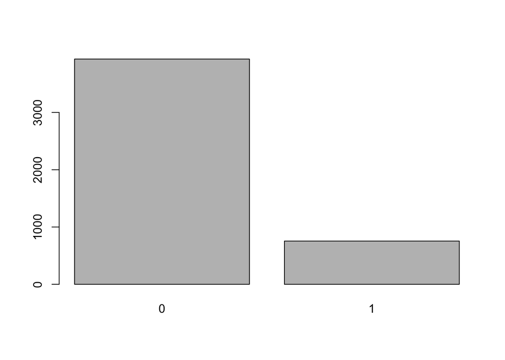

```r
asteroids$Hazardous %>% table() %>% barplot()
```

> The target proportion is imbalanced. Let’s upsample!

### Upsample the data

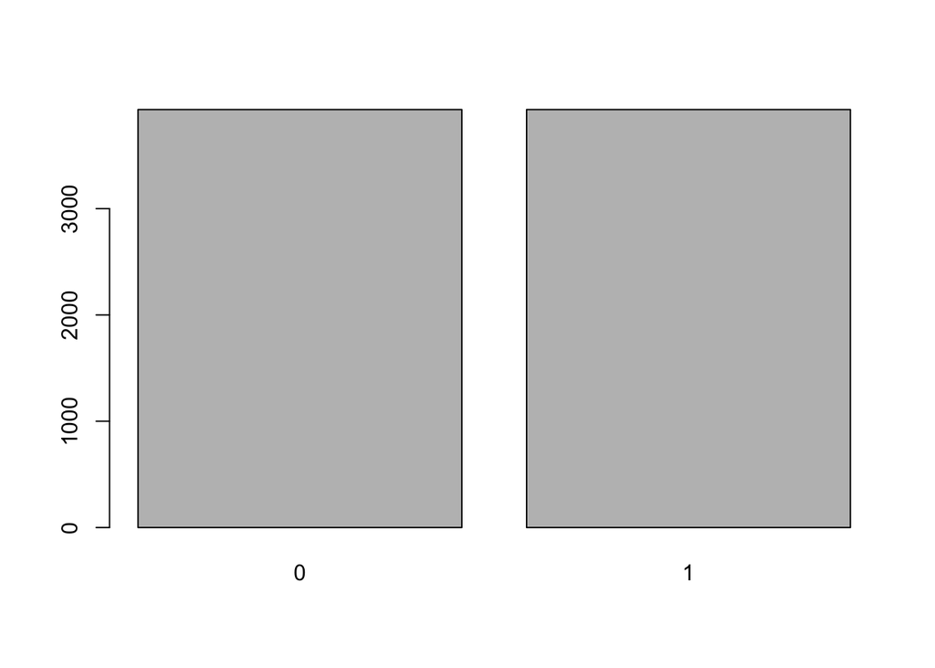

```r
up_asteroids <- upSample(x = asteroids %>% select(-Hazardous),
                         y = asteroids$Hazardous,
                         yname = "Hazardous")

up_asteroids$Hazardous %>% table() %>% barplot()
```

> Cool. It’s balanced now!

### Inspect categorical columns distributions

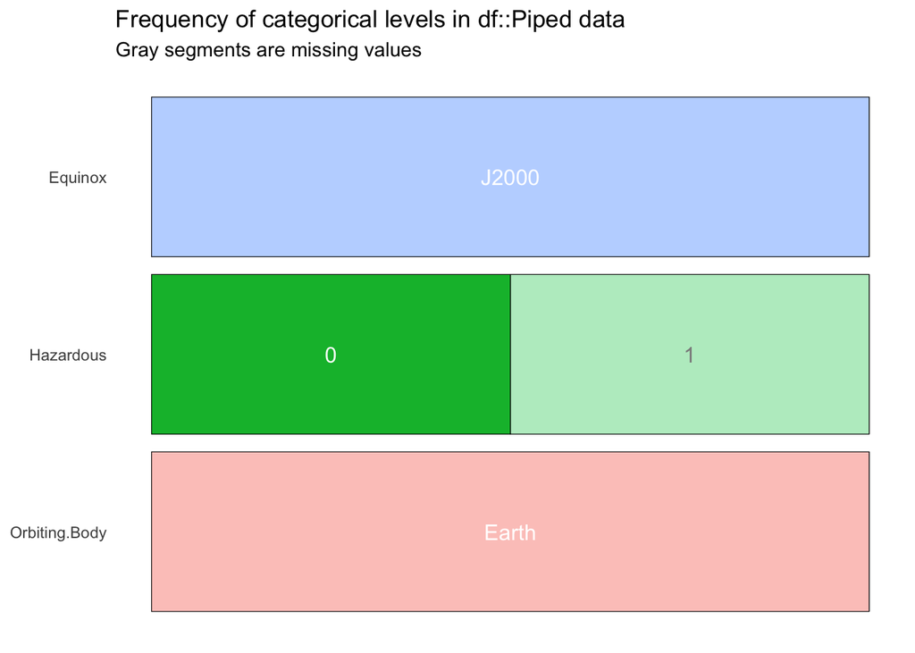

```r
up_asteroids %>% inspect_cat() %>% show_plot()
```

> The column `Equinox` and `Orbiting.Body` has 0 variance. Let’s remove them!

### Remove zero variance columns

```r
up_asteroids <- up_asteroids %>% select(-Equinox,
                                        -Orbiting.Body)

up_asteroids %>% head(3)
```

|  | Absolute.Magnitude | Est.Dia.in.KM.min. | Est.Dia.in.KM.max. | Est.Dia.in.M.min. | Est.Dia.in.M.max. | Est.Dia.in.Miles.min. | Est.Dia.in.Miles.max. | Est.Dia.in.Feet.min. | Est.Dia.in.Feet.max. | Epoch.Date.Close.Approach | Relative.Velocity.km.per.sec | Relative.Velocity.km.per.hr | Miles.per.hour | Miss.Dist..Astronomical. | Miss.Dist..lunar. | Miss.Dist..kilometers. | Miss.Dist..miles. | Orbit.Uncertainity | Minimum.Orbit.Intersection | Jupiter.Tisserand.Invariant | Epoch.Osculation | Eccentricity | Semi.Major.Axis | Inclination | Asc.Node.Longitude | Orbital.Period | Perihelion.Distance | Perihelion.Arg | Aphelion.Dist | … |
| --- | --- | --- | --- | --- | --- | --- | --- | --- | --- | --- | --- | --- | --- | --- | --- | --- | --- | --- | --- | --- | --- | --- | --- | --- | --- | --- | --- | --- | --- | --- |
| 1 | 21.3 | 0.146067964 | 0.32661790 | 146.067964 | 326.61790 | 0.090762397 | 0.2029509 | 479.2256 | 1071.58106 | 788947200000 | 18.11399 | 65210.35 | 40519.17 | 0.3830145 | 148.9926 | 57298148 | 35603420 | 3 | 0.1869350 | 5.457 | 2458000 | 0.3516743 | 1.107776 | 28.412996 | 136.71724 | 425.8693 | 0.7181996 | 313.0920 | 1.497352 | … |
| 2 | 27.4 | 0.008801465 | 0.01968067 | 8.801465 | 19.68067 | 0.005468975 | 0.0122290 | 28.8762 | 64.56914 | 790156800000 | 11.17387 | 40225.95 | 24994.84 | 0.2853223 | 110.9904 | 42683616 | 26522368 | 6 | 0.0055118 | 5.093 | 2458000 | 0.2165783 | 1.255903 | 7.905894 | 57.17327 | 514.0821 | 0.9839016 | 18.7077 | 1.527904 | … |
| 3 | 19.6 | 0.319561887 | 0.71456210 | 319.561887 | 714.56210 | 0.198566489 | 0.4440082 | 1048.4314 | 2344.36393 | 790156800000 | 10.80884 | 38911.84 | 24178.30 | 0.3927848 | 152.7933 | 58759768 | 36511628 | 1 | 0.2722130 | 4.724 | 2458000 | 0.5634411 | 1.323532 | 17.927751 | 178.97195 | 556.1606 | 0.5777998 | 198.1460 | 2.069265 | … |

### Inspect numerical columns distributions

```r
up_asteroids %>% select_if(is.numeric) %>% summary()
```

```
##  Absolute.Magnitude Est.Dia.in.KM.min.  Est.Dia.in.KM.max. Est.Dia.in.M.min.
##  Min.   :11.16      Min.   : 0.001011   Min.   : 0.00226   Min.   :    1.011
##  1st Qu.:19.60      1st Qu.: 0.076658   1st Qu.: 0.17141   1st Qu.:   76.658
##  Median :21.00      Median : 0.167708   Median : 0.37501   Median :  167.708
##  Mean   :21.40      Mean   : 0.249889   Mean   : 0.55877   Mean   :  249.889
##  3rd Qu.:22.70      3rd Qu.: 0.319562   3rd Qu.: 0.71456   3rd Qu.:  319.562
##  Max.   :32.10      Max.   :15.579552   Max.   :34.83694   Max.   :15579.552
##  Est.Dia.in.M.max.  Est.Dia.in.Miles.min. Est.Dia.in.Miles.max.
##  Min.   :    2.26   Min.   :0.000628      Min.   : 0.001404
##  1st Qu.:  171.41   1st Qu.:0.047633      1st Qu.: 0.106510
##  Median :  375.01   Median :0.104209      Median : 0.233019
##  Mean   :  558.77   Mean   :0.155274      Mean   : 0.347203
##  3rd Qu.:  714.56   3rd Qu.:0.198566      3rd Qu.: 0.444008
##  Max.   :34836.94   Max.   :9.680682      Max.   :21.646663
##  Est.Dia.in.Feet.min. Est.Dia.in.Feet.max. Epoch.Date.Close.Approach
##  Min.   :    3.32     Min.   :     7.41    Min.   :7.889e+11
##  1st Qu.:  251.50     1st Qu.:   562.37    1st Qu.:9.905e+11
##  Median :  550.22     Median :  1230.34    Median :1.182e+12
##  Mean   :  819.85     Mean   :  1833.23    Mean   :1.164e+12
##  3rd Qu.: 1048.43     3rd Qu.:  2344.36    3rd Qu.:1.344e+12
##  Max.   :51114.02     Max.   :114294.42    Max.   :1.473e+12
##  Relative.Velocity.km.per.sec Relative.Velocity.km.per.hr Miles.per.hour
##  Min.   : 0.3355              Min.   :  1208              Min.   :  750.5
##  1st Qu.: 9.6670              1st Qu.: 34801              1st Qu.:21624.2
##  Median :14.2036              Median : 51133              Median :31772.0
##  Mean   :15.2773              Mean   : 54998              Mean   :34173.7
##  3rd Qu.:19.5768              3rd Qu.: 70476              3rd Qu.:43791.3
##  Max.   :44.6337              Max.   :160681              Max.   :99841.2
##  Miss.Dist..Astronomical. Miss.Dist..lunar.   Miss.Dist..kilometers.
##  Min.   :0.0001779        Min.   :  0.06919   Min.   :   26610
##  1st Qu.:0.1391497        1st Qu.: 54.12924   1st Qu.:20816502
##  Median :0.2732463        Median :106.29281   Median :40877064
##  Mean   :0.2626487        Mean   :102.17036   Mean   :39291694
##  3rd Qu.:0.3901572        3rd Qu.:151.77116   3rd Qu.:58366688
##  Max.   :0.4998841        Max.   :194.45491   Max.   :74781600
##  Miss.Dist..miles.  Orbit.Uncertainity Minimum.Orbit.Intersection
##  Min.   :   16535   Min.   :0.000      Min.   :0.0000021
##  1st Qu.:12934775   1st Qu.:0.000      1st Qu.:0.0127533
##  Median :25399830   Median :1.000      Median :0.0296974
##  Mean   :24414727   Mean   :2.578      Mean   :0.0582420
```

[output cut: 15 more lines]

```
##  Max.   :5.0720   Max.   :75.40667   Max.   :359.9059   Max.   :4172.2
##  Perihelion.Distance Perihelion.Arg     Aphelion.Dist    Perihelion.Time
##  Min.   :0.08074     Min.   :  0.0069   Min.   :0.8038   Min.   :2450100
##  1st Qu.:0.58926     1st Qu.: 97.4822   1st Qu.:1.3002   1st Qu.:2457826
##  Median :0.78809     Median :193.9037   Median :1.6712   Median :2457983
##  Mean   :0.76705     Mean   :184.6180   Mean   :2.0180   Mean   :2457758
##  3rd Qu.:0.95089     3rd Qu.:268.1775   3rd Qu.:2.4768   3rd Qu.:2458108
##  Max.   :1.29983     Max.   :359.9931   Max.   :8.9839   Max.   :2458839
##   Mean.Anomaly       Mean.Motion
##  Min.   :  0.0032   Min.   :0.08628
##  1st Qu.: 96.2437   1st Qu.:0.46277
##  Median :191.2148   Median :0.71971
##  Mean   :187.2033   Mean   :0.74210
##  3rd Qu.:281.9666   3rd Qu.:0.97666
##  Max.   :359.9180   Max.   :2.03900
```

## **Cross Validation**

### Set training indices

Because we don’t have a lot of records, we will set the training proportion to 85%

```r
set.seed(1)
indices <- createDataPartition(y = up_asteroids$Hazardous,
                               p = 0.85,
                               list = F)
```

### Split train & test

```r
train_data <- up_asteroids[indices, ]
test_data <- up_asteroids[-indices, ]

X_train <- train_data %>% select(-Hazardous)
X_test <- test_data %>% select(-Hazardous)

y_train <- train_data$Hazardous
y_test <- test_data$Hazardous
```

## **Model Fitting, Evaluation, & Selection**

### Naive Bayes Algorithm

```r
model_nb <- naiveBayes(x = X_train,
                       y = y_train,
                       laplace = 1)
```

### Naive Bayes Model Evaluation

```r
pred_nb <- predict(model_nb, X_test)

confusionMatrix(pred_nb, y_test)
```

```
## Confusion Matrix and Statistics
##
##           Reference
## Prediction   0   1
##          0 549  35
##          1  40 554
##
##                Accuracy : 0.9363
##                  95% CI : (0.9208, 0.9496)
##     No Information Rate : 0.5
##     P-Value [Acc > NIR] : <2e-16
##
##                   Kappa : 0.8727
##
##  Mcnemar's Test P-Value : 0.6442
##
##             Sensitivity : 0.9321
##             Specificity : 0.9406
##          Pos Pred Value : 0.9401
##          Neg Pred Value : 0.9327
##              Prevalence : 0.5000
##          Detection Rate : 0.4660
##    Detection Prevalence : 0.4958
##       Balanced Accuracy : 0.9363
##
##        'Positive' Class : 0
##
```

> The focused metric for our evaluation is `Accuracy`. Why? Because in the realm of hazardous asteroid detections, it’s crucial to ensure a reliable overall performance in identifying both hazardous and non-hazardous instances.

> `NOTE:` Due to the unpredictable nature of R Markdown rendering, the generated scores might differ when the document is converted to HTML

### Logistic Regression Algorithm

```r
model_lgr <- glm(Hazardous ~ ., "binomial", train_data)
```

### Logistic Regression Evaluation

```r
pred_lgr <-  ifelse(predict(model_lgr, X_test) > 0.5, 1, 0) %>% as.factor()

confusionMatrix(pred_lgr, y_test)
```

```
## Confusion Matrix and Statistics
##
##           Reference
## Prediction   0   1
##          0 558  37
##          1  31 552
##
##                Accuracy : 0.9423
##                  95% CI : (0.9274, 0.9549)
##     No Information Rate : 0.5
##     P-Value [Acc > NIR] : <2e-16
##
##                   Kappa : 0.8846
##
##  Mcnemar's Test P-Value : 0.5443
##
##             Sensitivity : 0.9474
##             Specificity : 0.9372
##          Pos Pred Value : 0.9378
##          Neg Pred Value : 0.9468
##              Prevalence : 0.5000
##          Detection Rate : 0.4737
##    Detection Prevalence : 0.5051
##       Balanced Accuracy : 0.9423
##
##        'Positive' Class : 0
##
```

### Random Forest Algorithm

```r
ctrl <- trainControl(method = "repeatedcv",
                     number = 3,
                     repeats = 5)

model_rf <- train(Hazardous ~ .,
                  data = train_data,
                  method = "rf",
                  trConrol = ctrl,
                  ntree = 101)
```

### Random Forest Model Evaluation

```r
pred_rf <- predict(model_rf, X_test)

confusionMatrix(pred_rf, y_test)
```

```
## Confusion Matrix and Statistics
##
##           Reference
## Prediction   0   1
##          0 589   0
##          1   0 589
##
##                Accuracy : 1
##                  95% CI : (0.9969, 1)
##     No Information Rate : 0.5
##     P-Value [Acc > NIR] : < 2.2e-16
##
##                   Kappa : 1
##
##  Mcnemar's Test P-Value : NA
##
##             Sensitivity : 1.0
##             Specificity : 1.0
##          Pos Pred Value : 1.0
##          Neg Pred Value : 1.0
##              Prevalence : 0.5
##          Detection Rate : 0.5
##    Detection Prevalence : 0.5
##       Balanced Accuracy : 1.0
##
##        'Positive' Class : 0
##
```

> The random forest model demonstrated remarkable performance, achieving an exceptional `Accuracy of 100%`, making it the `winner model of this project!`. Furthermore, the model achieved a `Sensitivity of 100%` and `Specificity of 100%`. This outstanding performance reflects the model’s ability to flawlessly distinguish hazardous asteroids from non-hazardous ones. Such high sensitivity and specificity are instrumental in identifying and classifying objects accurately, underscoring the model’s reliability in predicting hazardous asteroids. This level of precision is of paramount importance for effective early detection and risk assessment, contributing to enhanced planetary safety and preparedness.

## **AUC of ROC**

My way of explaining the AUC of ROC score is that it reflects the level of certainty our model has in its predictions. A high AUC of ROC score indicates that the model is very confident and sure of its predictions. As people who use the model, we want the model to be highly confident in its predictions since we rely on it for making decisions. We don’t want a model that isn’t sure or confident about its predictions. This is why the AUC or ROC score is a crucial measure to determine if the model is prepared for practical use or not.

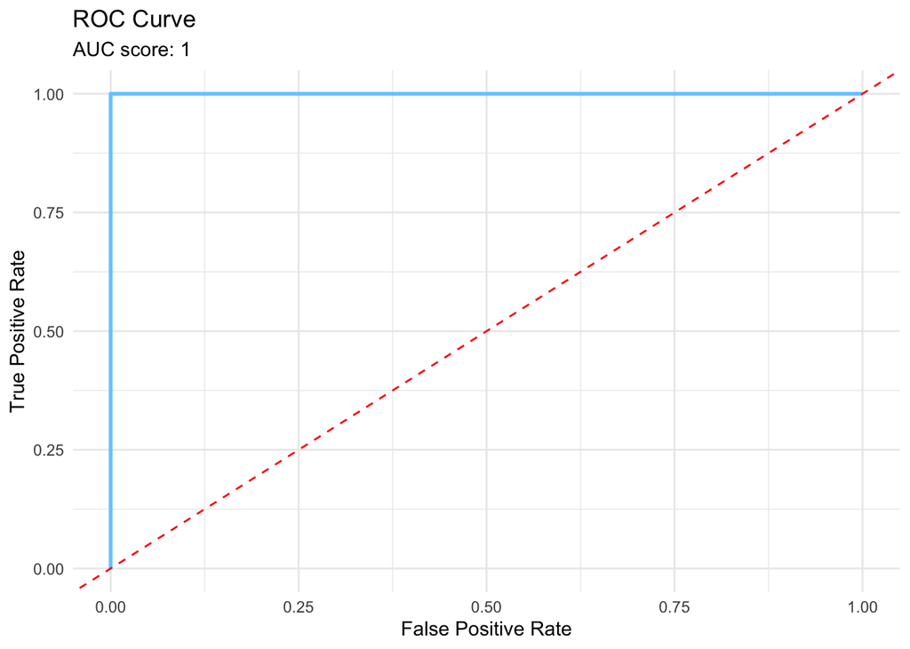

```r
pred_rf_raw <- predict(model_rf, X_test, type = "prob")

plotROC(pred_rf_raw[, 2], y_test) # This function is from my personal package
```

> Magnificent. Why? Because the closer the AUC to 1 the more confident the model is at detecting which asteroids are hazardous and which are not

## **Conclusion**

In conclusion, the final model developed for hazardous asteroid detection, which is the random forest model, stands as an exceptional achievement in predictive modeling. With an extraordinary Accuracy of 100% and Sensitivity of 100%, the model showcases unparalleled precision in identifying hazardous asteroids. This model also demonstrates perfect Specificity of 100%, further highlighting its ability to accurately differentiate non-hazardous asteroids.

Moreover, the AUC of ROC score of 1.0, representing a perfect score, serves as a resounding validation of the model’s readiness for practical deployment. This impeccable AUC score underscores the model’s absolute confidence in distinguishing between hazardous and non-hazardous asteroids. The model’s remarkable performance across all evaluation metrics solidifies its position as a reliable and robust tool for effectively detecting potential asteroid threats.

The flawless performance achieved by the random forest model, marked by its perfect accuracy, sensitivity, and specificity, attests to its exceptional competence in the realm of hazardous asteroid detection. With its unprecedented performance metrics, the model stands as a testament to its preparedness for real-world application, offering invaluable contributions to planetary defense and safety.